# Analysis

### 產業缺工與員工過剩關聯分析

在這份文件中，我們想研究是否存在過剩與短缺之間的簡單關聯，即過剩減少是否意味著短缺增加。本文我們分析了過剩與短缺之間的相關性。

```python
import pandas as pd
import numpy as np
import matplotlib.pyplot as plt

file_path1 = './data/labour_shortage_processed.xlsx'
df_shortage = pd.read_excel(file_path1)

file_path2 = './data/labourExcess_processed.xlsx'
df_excess = pd.read_excel(file_path2)
```

```python
df_merge = pd.merge(df_shortage, df_excess, how = 'left', on =['seq','year'])
df_merge.head()
```

|  | seq | emp | shortage | ratio | year | excess |
| --- | --- | --- | --- | --- | --- | --- |
| 0 | 1 | 6829 | 7 | 0.001025 | 2004 | 10.65 |
| 1 | 2 | 2426641 | 59574 | 0.024550 | 2004 | 11.64 |
| 2 | 3 | 374928 | 6402 | 0.017075 | 2004 | NaN |
| 3 | 4 | 34404 | 31 | 0.000901 | 2004 | 6.09 |
| 4 | 5 | 1410484 | 16822 | 0.011926 | 2004 | 5.46 |

我們選取emp、shortage、ratio和excess四個變數，計算彼此的皮爾森相關係數。

```python
df = pd.DataFrame(df_merge, columns = ['emp','shortage','ratio','excess'])
df.corr()
```

|  | emp | shortage | ratio | excess |
| --- | --- | --- | --- | --- |
| emp | 1.000000 | 0.961752 | -0.008346 | 0.220195 |
| shortage | 0.961752 | 1.000000 | 0.119525 | 0.219826 |
| ratio | -0.008346 | 0.119525 | 1.000000 | -0.300645 |
| excess | 0.220195 | 0.219826 | -0.300645 | 1.000000 |

如表格所見，shortage ratio 和 Excess ratio 有 -0.3的相關係數。顯示缺工比例與員工過剩廠商比例確實有一定程度的交替關係。即過剩人數越少，缺工人數越多；反之，過剩人數越多，缺工人數越少。

#### Significance

由於希望了解該相關係數是否統計上顯著，假設虛無假設$H_0$：excess和ratio的相關係數$\rho$為0。以bootstrap方式計算$\rho$的標準差，建構95%信賴區間。

```python
corr_sample = np.array([df.sample(len(df), replace = True).corr().iloc[2,3] for i in range(2000)])
corr_std = float(np.std(corr_sample))
corr_std
```

```
0.07283357142610376
```

計算而得$\rho$的標準差為0.073。

```python
corr = float(df.corr().iloc[2,3])
corr_interval = [corr -1.96*corr_std, corr + corr_std]
print(f"The confidential interval of correlation is {corr_interval}")
```

```
The confidential interval of correlation is [-0.44339852125001966, -0.2278111498287525]
```

## 同時考慮缺工與過剩

從上述研究發現，雖然缺工與過剩確實具有相關性，但是無論缺工的程度是輕是重，都存在員工過剩的情形；欲衡量產業之中的mis-allocation，應同時考慮缺工與過剩。有鑑於此，我們考慮員工過剩廠商比例與缺工比例的比值。其直觀意義為：各個產業在缺工比例相同的情況下，過剩的程度如何？

```python
df_merge['excess_shortage_ratio'] = df['excess']/df['ratio']
df_merge['excess_shortage_ratio']
```

```
0      10389.835714
1        474.134710
2               NaN
3       6758.721290
4        457.807790
           ...
228             NaN
229             NaN
230             NaN
231             NaN
232             NaN
Name: excess_shortage_ratio, Length: 233, dtype: float64
```

```python
pivot_df = df_merge.pivot(index = 'year', columns = 'seq', values = 'excess_shortage_ratio')
pivot_df
```

| seq year | 1 | 2 | 3 | 4 | 5 | 7 | 9 | 10 | 11 | 12 | 14 | 15 | 16 | 68 |
| --- | --- | --- | --- | --- | --- | --- | --- | --- | --- | --- | --- | --- | --- | --- |
| 2004 | 1.038984e+04 | 474.134710 | NaN | 6758.721290 | 457.807790 | NaN | 761.712972 | 1427.778479 | 323.663234 | NaN | NaN | 325.796336 | 473.286915 | NaN |
| 2005 | 1.853100e+03 | 477.609363 | NaN | 292.330547 | 458.164547 | 221.012128 | 742.021176 | 585.097921 | 361.874584 | NaN | NaN | 339.002035 | 266.753991 | NaN |
| 2006 | NaN | NaN | NaN | NaN | NaN | NaN | NaN | NaN | NaN | NaN | NaN | NaN | NaN | NaN |
| 2007 | 1.057692e+03 | 199.942048 | NaN | 211.215852 | 214.059403 | 1034.786106 | 38.616162 | 60.255923 | 99.107447 | NaN | NaN | 460.702119 | 145.255647 | NaN |
| 2008 | 4.015236e+03 | 318.830833 | NaN | 205.293022 | 683.048367 | 73.169064 | 435.152296 | 151.020559 | 191.276413 | NaN | NaN | 839.407123 | 366.866215 | NaN |
| 2009 | 8.706004e+03 | 442.745916 | NaN | 455.363650 | 272.833026 | 646.531266 | 58.628071 | 14.652822 | 133.374263 | 374.131157 | NaN | 295.593878 | 128.637132 | NaN |
| 2010 | inf | 152.824520 | NaN | 139.367289 | 191.062601 | 131.635415 | 25.055864 | 26.453922 | 177.426495 | 10.039786 | NaN | 121.085674 | 50.603356 | NaN |
| 2011 | 3.077922e+02 | 113.890550 | NaN | 107.630765 | 155.773303 | 1.333333 | 6.597067 | 0.735473 | 47.468722 | 80.088921 | NaN | 181.366207 | 36.469450 | NaN |
| 2012 | 3.256410e+02 | 155.291843 | NaN | 156.568972 | 62.938446 | 52.869752 | 28.394865 | 0.483092 | 107.010851 | 23.432412 | NaN | 13.407722 | 38.234648 | NaN |
| 2013 | 8.981269e+02 | 208.320917 | NaN | 125.921063 | 151.192893 | 104.214605 | 160.716993 | 49.714916 | 131.722442 | 186.513853 | NaN | 173.211497 | 46.515510 | NaN |
| 2014 | 1.043421e+02 | 140.572650 | NaN | 78.999797 | 54.941443 | 61.397278 | 37.273234 | 22.289183 | 86.991859 | 54.247807 | NaN | 6.014022 | 2.040127 | NaN |
| 2015 | 1.491304e+02 | 228.231348 | NaN | 0.000000 | 117.293153 | 71.090222 | 29.966614 | 69.198087 | 54.501927 | 64.632841 | NaN | 7.673663 | 45.127979 | NaN |
| 2016 | 5.171562e+02 | 236.433424 | NaN | 221.828434 | 167.378841 | 0.000000 | 14.168212 | 68.853661 | 230.422066 | 130.952534 | NaN | 17.935374 | 0.000000 | NaN |
| 2017 | NaN | NaN | NaN | NaN | NaN | NaN | NaN | NaN | NaN | NaN | NaN | NaN | NaN | NaN |
| 2018 | NaN | NaN | NaN | NaN | NaN | NaN | NaN | NaN | NaN | NaN | NaN | NaN | NaN | NaN |
| 2019 | NaN | NaN | NaN | NaN | NaN | NaN | NaN | NaN | NaN | NaN | NaN | NaN | NaN | NaN |
| 2020 | NaN | NaN | NaN | NaN | NaN | NaN | NaN | NaN | NaN | NaN | NaN | NaN | NaN | NaN |

```python
df_draw = pivot_df.drop([1,4,14,68],axis = 1, inplace = False).drop([2017,2018,2019,2020], axis = 0, inplace = False)
df_draw
```

| seq year | 2 | 3 | 5 | 7 | 9 | 10 | 11 | 12 | 15 | 16 |
| --- | --- | --- | --- | --- | --- | --- | --- | --- | --- | --- |
| 2004 | 474.134710 | NaN | 457.807790 | NaN | 761.712972 | 1427.778479 | 323.663234 | NaN | 325.796336 | 473.286915 |
| 2005 | 477.609363 | NaN | 458.164547 | 221.012128 | 742.021176 | 585.097921 | 361.874584 | NaN | 339.002035 | 266.753991 |
| 2006 | NaN | NaN | NaN | NaN | NaN | NaN | NaN | NaN | NaN | NaN |
| 2007 | 199.942048 | NaN | 214.059403 | 1034.786106 | 38.616162 | 60.255923 | 99.107447 | NaN | 460.702119 | 145.255647 |
| 2008 | 318.830833 | NaN | 683.048367 | 73.169064 | 435.152296 | 151.020559 | 191.276413 | NaN | 839.407123 | 366.866215 |
| 2009 | 442.745916 | NaN | 272.833026 | 646.531266 | 58.628071 | 14.652822 | 133.374263 | 374.131157 | 295.593878 | 128.637132 |
| 2010 | 152.824520 | NaN | 191.062601 | 131.635415 | 25.055864 | 26.453922 | 177.426495 | 10.039786 | 121.085674 | 50.603356 |
| 2011 | 113.890550 | NaN | 155.773303 | 1.333333 | 6.597067 | 0.735473 | 47.468722 | 80.088921 | 181.366207 | 36.469450 |
| 2012 | 155.291843 | NaN | 62.938446 | 52.869752 | 28.394865 | 0.483092 | 107.010851 | 23.432412 | 13.407722 | 38.234648 |
| 2013 | 208.320917 | NaN | 151.192893 | 104.214605 | 160.716993 | 49.714916 | 131.722442 | 186.513853 | 173.211497 | 46.515510 |
| 2014 | 140.572650 | NaN | 54.941443 | 61.397278 | 37.273234 | 22.289183 | 86.991859 | 54.247807 | 6.014022 | 2.040127 |
| 2015 | 228.231348 | NaN | 117.293153 | 71.090222 | 29.966614 | 69.198087 | 54.501927 | 64.632841 | 7.673663 | 45.127979 |
| 2016 | 236.433424 | NaN | 167.378841 | 0.000000 | 14.168212 | 68.853661 | 230.422066 | 130.952534 | 17.935374 | 0.000000 |

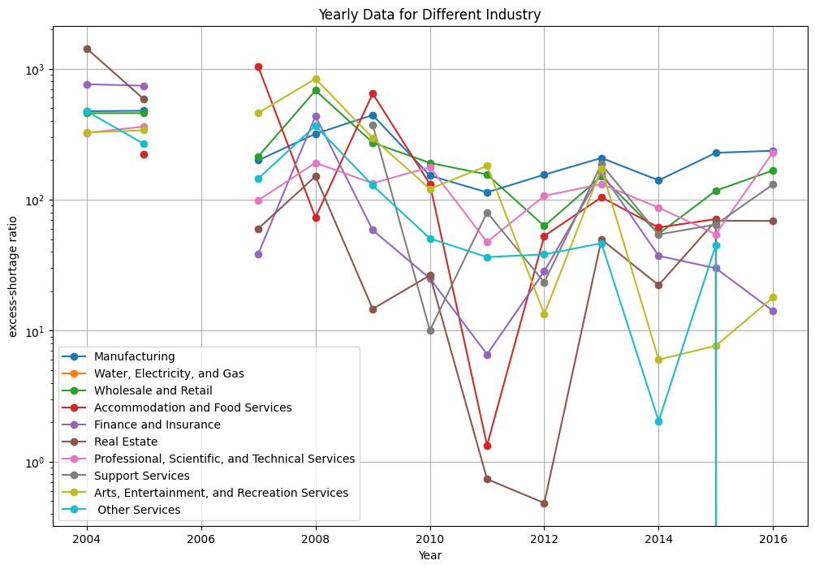

```python
industry_mapping = pd.read_excel('./data/IndustryMappingTable.xlsx')

# draw a picture
plt.figure(figsize=(12, 8))
for column in df_draw.columns:
    plt.plot(df_draw.index, df_draw[column], marker='o', label=f'{industry_mapping[industry_mapping["seq"] == column]["industry"].values[0]}')

plt.title('Yearly Data for Different Industry')
plt.xlabel('Year')
plt.ylabel('excess-shortage ratio')
plt.yscale('log')  # 使用對數刻度，因為數據跨度較大
plt.legend()
plt.grid(True)
plt.show()
```

```python
pivot_df[pivot_df.index < 2011].mean().sort_values(ascending = False)
```

```
seq
1             inf
4     1343.715275
7      421.426796
15     396.931194
5      379.495956
10     377.543271
2      344.347899
9      343.531090
16     238.567209
11     214.453739
12     192.085471
3             NaN
14            NaN
68            NaN
dtype: float64
```

我們將各個產業的mis-allocation在製造業實施3k五級制(2011)之前的數值取平均並排名，發現製造製造業在所有的產業之中的mis-allocation狀況並無特別之處，處於前段班者的產業還包含批發零售業，藝術娛樂文化休閒業、以及住宿餐飲業等。

```python
pivot_df[pivot_df.index >= 2011].mean().sort_values(ascending = False)
```

```
seq
1     383.698155
2     180.456789
5     118.253013
4     115.158172
11    109.686311
12     89.978062
15     66.601414
7      48.484198
9      46.186164
10     35.212402
16     28.064619
3            NaN
14           NaN
68           NaN
dtype: float64
```

相對地，在實施3k五級制(2011)之後，反而可以注意到製造業的mis-allocation的狀況卻名列前茅。這個現象須帶進一步解釋與討論。

## 分析小結

從缺工與過剩的關係分析之中，我們首先發現過剩與缺工確實存在交互關係，即當缺工率上升時，過剩率也下降；相對地，當缺工率下降，過剩率上升。這反映了基本的供給需求關係，即當廠商對勞動力需求與供給的差距上升時，更多的受雇員工不被視為過剩，同時更多的職位釋放到市場當中；反之，當需求與供給的差距下降時，更多的受雇員工被視為過剩，市場中的空缺職位也減少。 其次，缺工與過剩總是在市場中並存的事實，使得我們了解到無論勞動市場中的需求與供給如何變化，產業之中總是存在工作職缺與求職者的mis-allocation。由是，我們透過考慮過剩率與缺工率的比值，分析各個產業其mis-allocation的狀況。 這導引到最後一個結論所欲回答的問題，即關於製造業是否比起其他產業，在缺工的狀況上更具有特殊之處？之所以考慮這個問題，是因為我們希望排除或減少3k五級制的實施與製造業具有的內生性。從最後一張圖可以發現，製造業實施3k五級制之前，在所有的產業之中的mis-allocation狀況並無特別之處，可以解釋為，製造業實施政策與其mis-allocation狀況的內生性狀況較不嚴重。